```python
import pandas as pd
import matplotlib.pyplot as plt
import numpy as np

trainData = pd.DataFrame(pd.read_csv("D:/Term5/AI/CA0/train.csv"))
```

# Question 1

```python
trainData.head()
```

|  | PassengerId | Survived | Pclass | Name | Sex | Age | SibSp | Parch | Ticket | Fare | Cabin | Embarked |
| --- | --- | --- | --- | --- | --- | --- | --- | --- | --- | --- | --- | --- |
| 0 | 1 | 0 | 3 | Braund, Mr. Owen Harris | male | 22.0 | 1 | 0 | A/5 21171 | 7.2500 | NaN | S |
| 1 | 2 | 1 | 1 | Cumings, Mrs. John Bradley (Florence Briggs Th... | female | 38.0 | 1 | 0 | PC 17599 | 71.2833 | C85 | C |
| 2 | 3 | 1 | 3 | Heikkinen, Miss. Laina | female | 26.0 | 0 | 0 | STON/O2. 3101282 | 7.9250 | NaN | S |
| 3 | 4 | 1 | 1 | Futrelle, Mrs. Jacques Heath (Lily May Peel) | female | 35.0 | 1 | 0 | 113803 | 53.1000 | C123 | S |
| 4 | 5 | 0 | 3 | Allen, Mr. William Henry | male | 35.0 | 0 | 0 | 373450 | 8.0500 | NaN | S |

```python
trainData.tail()
```

|  | PassengerId | Survived | Pclass | Name | Sex | Age | SibSp | Parch | Ticket | Fare | Cabin | Embarked |
| --- | --- | --- | --- | --- | --- | --- | --- | --- | --- | --- | --- | --- |
| 886 | 887 | 0 | 2 | Montvila, Rev. Juozas | male | 27.0 | 0 | 0 | 211536 | 13.00 | NaN | S |
| 887 | 888 | 1 | 1 | Graham, Miss. Margaret Edith | female | 19.0 | 0 | 0 | 112053 | 30.00 | B42 | S |
| 888 | 889 | 0 | 3 | Johnston, Miss. Catherine Helen "Carrie" | female | NaN | 1 | 2 | W./C. 6607 | 23.45 | NaN | S |
| 889 | 890 | 1 | 1 | Behr, Mr. Karl Howell | male | 26.0 | 0 | 0 | 111369 | 30.00 | C148 | C |
| 890 | 891 | 0 | 3 | Dooley, Mr. Patrick | male | 32.0 | 0 | 0 | 370376 | 7.75 | NaN | Q |

```python
trainData.info()
```

```
<class 'pandas.core.frame.DataFrame'>
RangeIndex: 891 entries, 0 to 890
Data columns (total 12 columns):
 #   Column       Non-Null Count  Dtype
---  ------       --------------  -----
 0   PassengerId  891 non-null    int64
 1   Survived     891 non-null    int64
 2   Pclass       891 non-null    int64
 3   Name         891 non-null    object
 4   Sex          891 non-null    object
 5   Age          714 non-null    float64
 6   SibSp        891 non-null    int64
 7   Parch        891 non-null    int64
 8   Ticket       891 non-null    object
 9   Fare         891 non-null    float64
 10  Cabin        204 non-null    object
 11  Embarked     889 non-null    object
dtypes: float64(2), int64(5), object(5)
memory usage: 83.7+ KB
```

```python
trainData.describe()
```

|  | PassengerId | Survived | Pclass | Age | SibSp | Parch | Fare |
| --- | --- | --- | --- | --- | --- | --- | --- |
| count | 891.000000 | 891.000000 | 891.000000 | 714.000000 | 891.000000 | 891.000000 | 891.000000 |
| mean | 446.000000 | 0.383838 | 2.308642 | 29.699118 | 0.523008 | 0.381594 | 32.204208 |
| std | 257.353842 | 0.486592 | 0.836071 | 14.526497 | 1.102743 | 0.806057 | 49.693429 |
| min | 1.000000 | 0.000000 | 1.000000 | 0.420000 | 0.000000 | 0.000000 | 0.000000 |
| 25% | 223.500000 | 0.000000 | 2.000000 | 20.125000 | 0.000000 | 0.000000 | 7.910400 |
| 50% | 446.000000 | 0.000000 | 3.000000 | 28.000000 | 0.000000 | 0.000000 | 14.454200 |
| 75% | 668.500000 | 1.000000 | 3.000000 | 38.000000 | 1.000000 | 0.000000 | 31.000000 |
| max | 891.000000 | 1.000000 | 3.000000 | 80.000000 | 8.000000 | 6.000000 | 512.329200 |

سوال1:  
تابع head نشان‌دهنده پنج سطر اول DataFrame است.  
تابع tail نشان‌دهنده پنج سطر آخر DataFrame است.  
تابع info اطلاعات روبه‌رو را نمایش می‌دهد و چیزی return نمی‌کند: رنج اندیس، تعداد ستون‌ها و نام هر ستون، تعداد سطرهای غیر null به ازای هر ستون، نوع داده‌های هر ستون و مصرف حافظه.  
تابع describe توصیف داده در DataFrame را برمی‌گرداند. اگر DataFrame شامل داده‌ی عددی باشد، این توصیف شامل موارد روبه‌رو است: تعداد سطرهای غیرخالی، میانگین داده‌ها، انحراف از معیار داده‌ها، مینیمم داده‌ها، چارک اول داده‌ها، چارک دوم داده‌ها، چارک سوم داده‌ها، بزرگترین داده.

# Question 2

```python
trainData['Sex'].replace(['female','male'],[0,1],inplace=True)

#the reason that I coded the embarked column is that its data is categorical and we need to have numerical data  in further questionsp
trainData['Embarked'].replace(['S','C','Q'],[0,1,2],inplace=True)

display(trainData)
```

|  | PassengerId | Survived | Pclass | Name | Sex | Age | SibSp | Parch | Ticket | Fare | Cabin | Embarked |
| --- | --- | --- | --- | --- | --- | --- | --- | --- | --- | --- | --- | --- |
| 0 | 1 | 0 | 3 | Braund, Mr. Owen Harris | 1 | 22.0 | 1 | 0 | A/5 21171 | 7.2500 | NaN | 0.0 |
| 1 | 2 | 1 | 1 | Cumings, Mrs. John Bradley (Florence Briggs Th... | 0 | 38.0 | 1 | 0 | PC 17599 | 71.2833 | C85 | 1.0 |
| 2 | 3 | 1 | 3 | Heikkinen, Miss. Laina | 0 | 26.0 | 0 | 0 | STON/O2. 3101282 | 7.9250 | NaN | 0.0 |
| 3 | 4 | 1 | 1 | Futrelle, Mrs. Jacques Heath (Lily May Peel) | 0 | 35.0 | 1 | 0 | 113803 | 53.1000 | C123 | 0.0 |
| 4 | 5 | 0 | 3 | Allen, Mr. William Henry | 1 | 35.0 | 0 | 0 | 373450 | 8.0500 | NaN | 0.0 |
| ... | ... | ... | ... | ... | ... | ... | ... | ... | ... | ... | ... | ... |
| 886 | 887 | 0 | 2 | Montvila, Rev. Juozas | 1 | 27.0 | 0 | 0 | 211536 | 13.0000 | NaN | 0.0 |
| 887 | 888 | 1 | 1 | Graham, Miss. Margaret Edith | 0 | 19.0 | 0 | 0 | 112053 | 30.0000 | B42 | 0.0 |
| 888 | 889 | 0 | 3 | Johnston, Miss. Catherine Helen "Carrie" | 0 | NaN | 1 | 2 | W./C. 6607 | 23.4500 | NaN | 0.0 |
| 889 | 890 | 1 | 1 | Behr, Mr. Karl Howell | 1 | 26.0 | 0 | 0 | 111369 | 30.0000 | C148 | 1.0 |
| 890 | 891 | 0 | 3 | Dooley, Mr. Patrick | 1 | 32.0 | 0 | 0 | 370376 | 7.7500 | NaN | 2.0 |

891 rows × 12 columns

```python
trainData.info(show_counts = False)
```

```
<class 'pandas.core.frame.DataFrame'>
RangeIndex: 891 entries, 0 to 890
Data columns (total 12 columns):
 #   Column       Dtype
---  ------       -----
 0   PassengerId  int64
 1   Survived     int64
 2   Pclass       int64
 3   Name         object
 4   Sex          int64
 5   Age          float64
 6   SibSp        int64
 7   Parch        int64
 8   Ticket       object
 9   Fare         float64
 10  Cabin        object
 11  Embarked     float64
dtypes: float64(3), int64(6), object(3)
memory usage: 83.7+ KB
```

# Question 3

```python
trainData.isna().sum()
```

```
PassengerId      0
Survived         0
Pclass           0
Name             0
Sex              0
Age            177
SibSp            0
Parch            0
Ticket           0
Fare             0
Cabin          687
Embarked         2
dtype: int64
```

```python
trainData.drop('Cabin', axis=1, inplace=True)
trainData["Age"].fillna(value=trainData["Age"].mean(), inplace=True)
display(trainData)
```

|  | PassengerId | Survived | Pclass | Name | Sex | Age | SibSp | Parch | Ticket | Fare | Embarked |
| --- | --- | --- | --- | --- | --- | --- | --- | --- | --- | --- | --- |
| 0 | 1 | 0 | 3 | Braund, Mr. Owen Harris | 1 | 22.000000 | 1 | 0 | A/5 21171 | 7.2500 | 0.0 |
| 1 | 2 | 1 | 1 | Cumings, Mrs. John Bradley (Florence Briggs Th... | 0 | 38.000000 | 1 | 0 | PC 17599 | 71.2833 | 1.0 |
| 2 | 3 | 1 | 3 | Heikkinen, Miss. Laina | 0 | 26.000000 | 0 | 0 | STON/O2. 3101282 | 7.9250 | 0.0 |
| 3 | 4 | 1 | 1 | Futrelle, Mrs. Jacques Heath (Lily May Peel) | 0 | 35.000000 | 1 | 0 | 113803 | 53.1000 | 0.0 |
| 4 | 5 | 0 | 3 | Allen, Mr. William Henry | 1 | 35.000000 | 0 | 0 | 373450 | 8.0500 | 0.0 |
| ... | ... | ... | ... | ... | ... | ... | ... | ... | ... | ... | ... |
| 886 | 887 | 0 | 2 | Montvila, Rev. Juozas | 1 | 27.000000 | 0 | 0 | 211536 | 13.0000 | 0.0 |
| 887 | 888 | 1 | 1 | Graham, Miss. Margaret Edith | 0 | 19.000000 | 0 | 0 | 112053 | 30.0000 | 0.0 |
| 888 | 889 | 0 | 3 | Johnston, Miss. Catherine Helen "Carrie" | 0 | 29.699118 | 1 | 2 | W./C. 6607 | 23.4500 | 0.0 |
| 889 | 890 | 1 | 1 | Behr, Mr. Karl Howell | 1 | 26.000000 | 0 | 0 | 111369 | 30.0000 | 1.0 |
| 890 | 891 | 0 | 3 | Dooley, Mr. Patrick | 1 | 32.000000 | 0 | 0 | 370376 | 7.7500 | 2.0 |

891 rows × 11 columns

سوال3:  
مزایا:  
استفاده از میانگین بسیار ساده است.  
میانگین داده‌ها ثابت می‌ماند؛ پس اگر تعدادی داده به طور رندوم از دست رفت، تخمین میانگین ثابت است.  
معایب:  
برای داده‌هایی که عددی نیستند قابل استفاده نیست.  
انحراف از معیار تغییر می‌کند و این روی نمودار توزیع داده‌ها تاثیر می‌گذارد و با اینکه سمت چپ و راست نمودار تقریبا با نمودار قبل از اعمال این تغییر یکسان است ولی در اطراف میانگین بیشترین تغییر وجود دارد.  
استفاده از این روش ارتباط بین متغیرهارا حفظ نمی‌کند و مقدار چارک‌ها را تغییر خواهد داد.

# Question 4

```python
trainData.drop('PassengerId', axis=1, inplace=True)
trainData.drop('Ticket', axis=1, inplace=True)
trainData.drop('Name', axis=1, inplace=True)
trainData.dropna(subset=['Embarked'], inplace = True)
trainData.reset_index(drop=True, inplace = True)
trainData.describe()
```

|  | Survived | Pclass | Sex | Age | SibSp | Parch | Fare | Embarked |
| --- | --- | --- | --- | --- | --- | --- | --- | --- |
| count | 889.000000 | 889.000000 | 889.000000 | 889.000000 | 889.000000 | 889.000000 | 889.000000 | 889.000000 |
| mean | 0.382452 | 2.311586 | 0.649044 | 29.653446 | 0.524184 | 0.382452 | 32.096681 | 0.362205 |
| std | 0.486260 | 0.834700 | 0.477538 | 12.968366 | 1.103705 | 0.806761 | 49.697504 | 0.636157 |
| min | 0.000000 | 1.000000 | 0.000000 | 0.420000 | 0.000000 | 0.000000 | 0.000000 | 0.000000 |
| 25% | 0.000000 | 2.000000 | 0.000000 | 22.000000 | 0.000000 | 0.000000 | 7.895800 | 0.000000 |
| 50% | 0.000000 | 3.000000 | 1.000000 | 29.699118 | 0.000000 | 0.000000 | 14.454200 | 0.000000 |
| 75% | 1.000000 | 3.000000 | 1.000000 | 35.000000 | 1.000000 | 0.000000 | 31.000000 | 1.000000 |
| max | 1.000000 | 3.000000 | 1.000000 | 80.000000 | 8.000000 | 6.000000 | 512.329200 | 2.000000 |

چون تعداد داده‌های NaN در ستون Embarked تنها 2 تاست پس این دو ردیف از داده را حذف کردیم.

# Question 5

```python
numberOfMen = trainData['Sex'].value_counts()[1]
print("The number of men is" , numberOfMen)
numberOfWomen = trainData['Sex'].value_counts()[0]
print("The number of women is" , numberOfWomen)

numberOfMenAtS = len(trainData.loc[(trainData['Sex'] == 1 ) & (trainData['Embarked'] == 0)])
print("The number of men embarked in Southampton is", numberOfMenAtS)
```

```
The number of men is 577
The number of women is 312
The number of men embarked in Southampton is 441
```

# Question 6

```python
numberOfOlderThan35WithoutAttendant3 = len(trainData.loc[(trainData['Age'] > 35) & (trainData['SibSp'] + trainData['Parch']  == 0)  & (trainData['Pclass'] == 3)])
print("number of passengers with given conditions is", numberOfOlderThan35WithoutAttendant3)
```

```
number of passengers with given conditions is 41
```

# Question 7

```python
def calcMeanVectorization():
     return trainData.loc[trainData['Embarked'] == 2]['Fare'].mean()
print("The mean of fare that passengers who enbarked in Queenstown payed is:", calcMeanVectorization())
```

```
The mean of fare that passengers who enbarked in Queenstown payed is: 13.276029870129872
```

# Question 8

```python
def calcMeanLoop():
    count = 0
    summation = 0
    for index, row in trainData.iterrows():
        if row['Embarked'] == 2:
            count += 1
            summation += row['Fare']
    return summation/count
print("The mean of fare that passengers who enbarked in Queenstown payed USING FOR LOOP is", calcMeanLoop())
```

```
The mean of fare that passengers who enbarked in Queenstown payed USING FOR LOOP is 13.276029870129872
```

```python
from timeit import timeit
num = 250
loopTime = timeit(calcMeanLoop, number=num)
print("loop time in 250 times running the code is", loopTime)
vectorizationTime = timeit(calcMeanVectorization, number=num)
print("vectorization time in 250 times running the code is", vectorizationTime)
print("Using vectorization is",(loopTime / vectorizationTime),"times faster than using loop in 250 times running the code")
```

```
loop time in 250 times running the code is 8.12825189999785
vectorization time in 250 times running the code is 0.10766870000225026
Using vectorization is 75.49317396632419 times faster than using loop in 250 times running the code
```

سوال8:  
همان‌طور که در بالا دیده می‌شود در 250 بار اجرا کردن برنامه سرعت vectorization حدود 75 برابر استفاده از loop است.

# Question 9

```
array([[<AxesSubplot:title={'center':'Survived'}>,
        <AxesSubplot:title={'center':'Pclass'}>,
        <AxesSubplot:title={'center':'Sex'}>],
       [<AxesSubplot:title={'center':'Age'}>,
        <AxesSubplot:title={'center':'SibSp'}>,
        <AxesSubplot:title={'center':'Parch'}>],
       [<AxesSubplot:title={'center':'Fare'}>,
        <AxesSubplot:title={'center':'Embarked'}>, <AxesSubplot:>]],
      dtype=object)
```

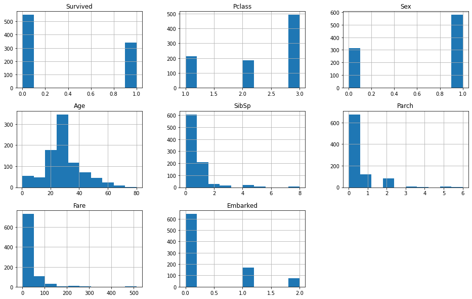

```python
trainData.hist(figsize=(16,10))
```

# Question 10

```
array([[<AxesSubplot:title={'center':'Survived'}>,
        <AxesSubplot:title={'center':'Pclass'}>,
        <AxesSubplot:title={'center':'Sex'}>],
       [<AxesSubplot:title={'center':'Age'}>,
        <AxesSubplot:title={'center':'SibSp'}>,
        <AxesSubplot:title={'center':'Parch'}>],
       [<AxesSubplot:title={'center':'Fare'}>,
        <AxesSubplot:title={'center':'Embarked'}>, <AxesSubplot:>]],
      dtype=object)
```

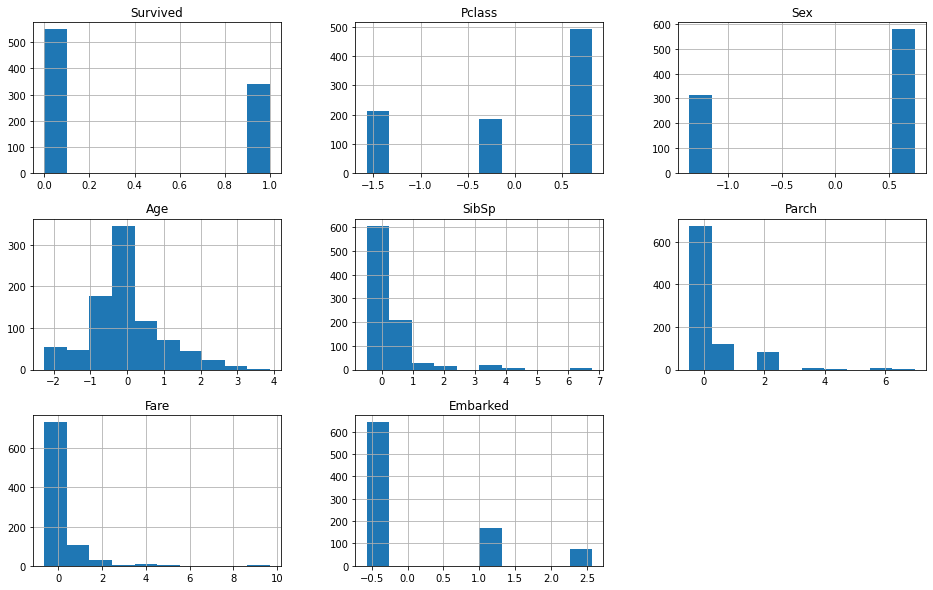

```python
normalizedTrainData = (trainData - trainData.mean(numeric_only = True)) / trainData.std(numeric_only = True)
normalizedTrainData['Survived'] = trainData['Survived']
normalizedTrainData.hist(figsize=(16,10))
```

ستون Survived را نرمال‌سازی نمی‌کنیم چون با اینکار داده‌ها عدد اعشاری می‌شوند و نمی‌توان به راحتی روی داده‌هایش بررسی انجام داد.

# Question 11

|  | Mean Of Survived | Mean Of Not Survived | Std Of Survived | Std Of Not Survived |
| --- | --- | --- | --- | --- |
| Pclass | -0.426146 | 0.263915 | 1.033621 | 0.881521 |
| Sex | -0.687811 | 0.425967 | 0.978751 | 0.743329 |
| Age | -0.094834 | 0.058732 | 1.055095 | 0.960597 |
| SibSp | -0.043231 | 0.026773 | 0.643141 | 1.167340 |
| Parch | 0.105601 | -0.065400 | 0.958346 | 1.020335 |
| Fare | 0.324218 | -0.200791 | 1.343101 | 0.631585 |
| Embarked | 0.138009 | -0.085470 | 1.025045 | 0.975354 |

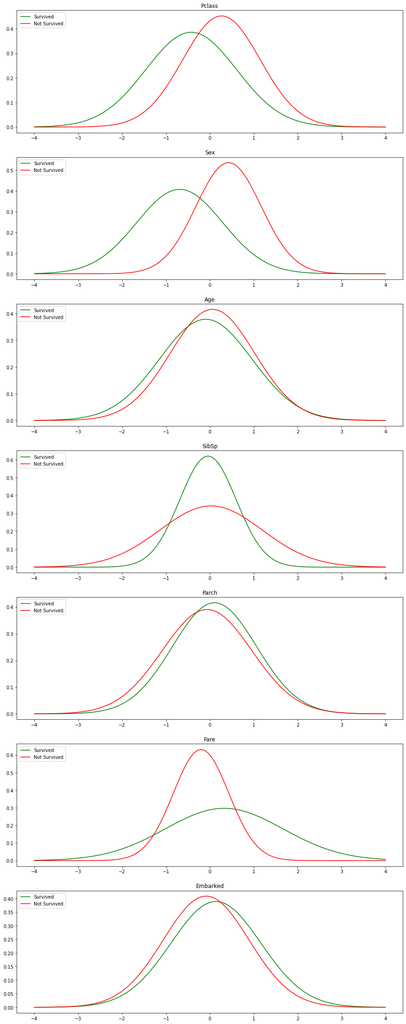

```python
meanOfSurvived = normalizedTrainData.loc[normalizedTrainData['Survived'] == 1].mean(numeric_only = True)
stdOfSurvived = normalizedTrainData.loc[normalizedTrainData['Survived'] == 1].std(numeric_only = True)
meanOfNotSurvived = normalizedTrainData.loc[normalizedTrainData['Survived'] == 0].mean(numeric_only = True)
stdOfNotSurvived = normalizedTrainData.loc[normalizedTrainData['Survived'] == 0].std(numeric_only = True)

dataBasedOnSurvived = pd.DataFrame({'Mean Of Survived' : meanOfSurvived, 'Mean Of Not Survived' : meanOfNotSurvived,
                                    'Std Of Survived' : stdOfSurvived, 'Std Of Not Survived' : stdOfNotSurvived})
dataBasedOnSurvived.drop('Survived', axis=0, inplace=True)
display(dataBasedOnSurvived)

import scipy.stats as sc

fig, ax = plt.subplots(nrows=len(dataBasedOnSurvived), ncols=1, figsize=(15, 40))
x_axis = np.linspace(-4, 4, 100)

def showNormalPlot(row, index, plotName, label, color, y):
    ax[index].plot(x_axis, y, label=label, c=color)
    ax[index].legend(loc='upper left')

for index, (plotName, row) in enumerate(dataBasedOnSurvived.iterrows()):
    y_survived =  sc.norm.pdf(x_axis,row['Mean Of Survived'],row['Std Of Survived'])
    showNormalPlot(row, index, plotName, 'Survived', 'green', y_survived)
    y_notSurvived =  sc.norm.pdf(x_axis,row['Mean Of Not Survived'],row['Std Of Not Survived'])
    showNormalPlot(row, index, plotName, 'Not Survived', 'red', y_notSurvived)
    ax[index].set_title(plotName)
```

سوال11:  
در اینجا باید ویژگی‌ای در نظر گرفته شود که دو نمودار کسانی که زنده می‌مانند و کسانی که زنده نمی‌مانند در آن اختلاف بیشتری داشته باشد؛ ما ویژگی جنسیت را در نظر گرفتیم چون در این ویژگی قله‌ی نمودار نرمال کسانی که زنده می‌مانند و زنده نمی‌مانند فاصله‌ی بیشتری از هم دارند و به تبع آن اختلاف دو نمودارد نمایان تر است.

# Question 12

```python
def getIntersectionPoints(meanS, meanN, stdS, stdN):
    intersectionPoints = np.roots([1 / (2 * stdS**2) - 1 / (2 * stdN**2), meanN / (stdN**2) - meanS / (stdS**2), meanS**2 / (2 * stdS**2) - meanN**2 / (2 * stdN**2) - np.log(stdN / stdS)])
    return intersectionPoints

sexInterPoints = getIntersectionPoints(dataBasedOnSurvived.loc['Sex']['Mean Of Survived'], dataBasedOnSurvived.loc['Sex']['Mean Of Not Survived'], dataBasedOnSurvived.loc['Sex']['Std Of Survived'], dataBasedOnSurvived.loc['Sex']['Std Of Not Survived'])

def doesSurvive(normalizedtest, intersectionPoints):
    if(intersectionPoints[0] < intersectionPoints[1]):
        min = intersectionPoints[0]
        max = intersectionPoints[1]
    else:
        min = intersectionPoints[1]
        max = intersectionPoints[0]

    if (min < normalizedtest < max):
        return 0
    return 1

testData = pd.DataFrame(pd.read_csv("D:/Term5/AI/CA0/test.csv"))

colNames = testData.columns.values.tolist()
for name in colNames:
    if(name != 'Sex'):
        testData.drop(name, axis=1, inplace=True)
testData['Sex'].replace(['female','male'],[0,1],inplace=True)
normalizedTestData =  (testData['Sex'] - trainData['Sex'].mean()) / trainData['Sex'].std()
finalResult = pd.DataFrame()
finalResult['Survived'] = normalizedTestData.apply(lambda normalizedtest: doesSurvive(normalizedtest, sexInterPoints))
display(finalResult)
finalResult.to_csv("D:/Term5/AI/CA0/finalResult.csv")
```

|  | Survived |
| --- | --- |
| 0 | 0 |
| 1 | 1 |
| 2 | 0 |
| 3 | 0 |
| 4 | 1 |
| ... | ... |
| 413 | 0 |
| 414 | 1 |
| 415 | 0 |
| 416 | 0 |
| 417 | 0 |

418 rows × 1 columns

سوال12:  
داده‌ی تست را با میانگین و انحراف از معیار داده‌ی train نرمال می‌کنیم و همچنین برای ویژگی Sex داده را با 0 و 1 مدل می‌کنیم. نقاط تقاطع دو نمودار را در ویژگی Sex و در داده‌ی train بدست می‌آوریم و طبق نمودار تعیین می‌کنیم که در چه جاهایی اکثرا نجات یافته‌اند و در چه جاهایی خیر و طبق آن نتیجه را برای داده‌ی test بدست می‌آوریم.